# Time Series Forecasting with Rice Production in INDIA Dataset

Subham Das

2022-11-05

Taking the Rice-Production Dataset

```r
library(readxl)
Book1 <- read_excel("D:\\DATASETS\\Rice_prod.xlsx")
Book1
```

```
## # A tibble: 71 x 2
##     Year `Rice production`
##    <dbl>             <dbl>
##  1  1950               206
##  2  1951               213
##  3  1952               229
##  4  1953               282
##  5  1954               252
##  6  1955               276
##  7  1956               290
##  8  1957               255
##  9  1958               309
## 10  1959               317
## # ... with 61 more rows
```

Making it as a Time-Series Dataset.

```r
Rice_production=ts(Book1$`Rice production`,start=1950,end=2020,frequency = 1)
```

Time-Series plot of the Data

```r
library(tseries)
```

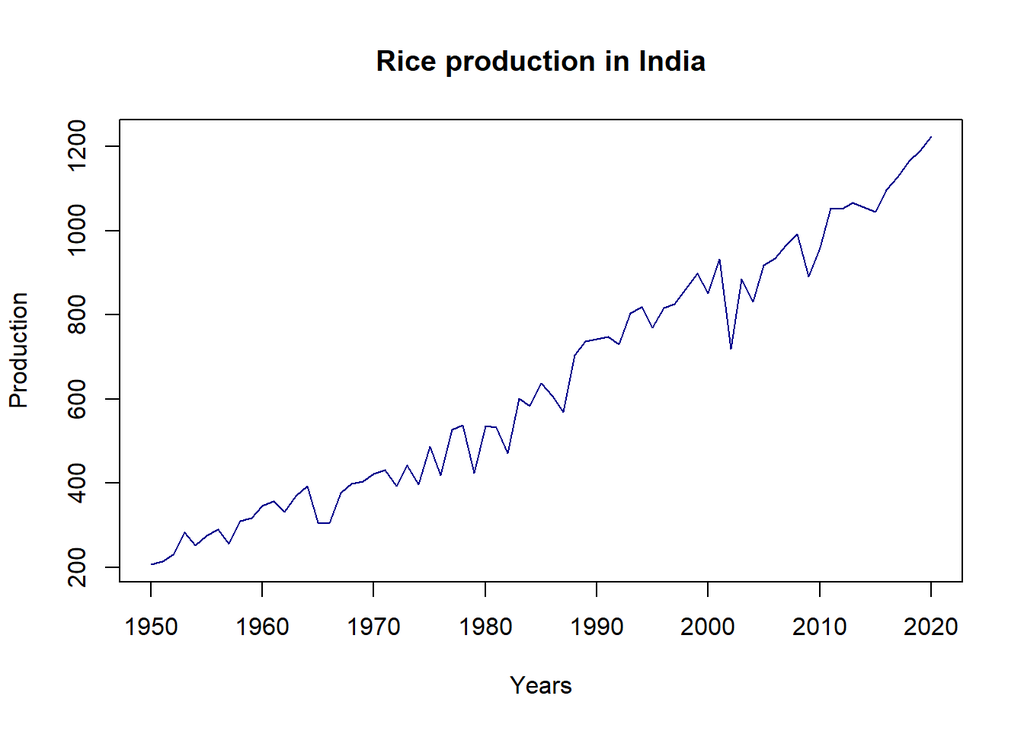

```r
ts.plot(Rice_production,main='Rice production in India', xlab='Years', ylab='Production', col='darkblue')
```

We can easily see that in this dataset only Trend component is present and no Seasonal component is present.

ACF of the Dataset

```r
library(forecast)
```

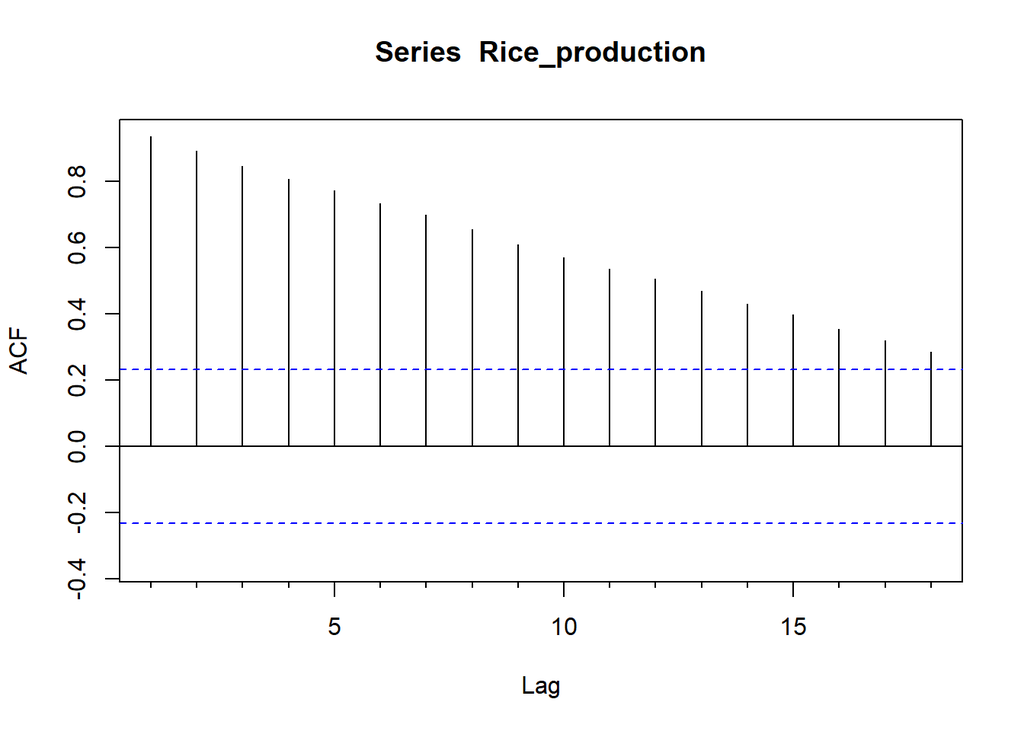

```r
Acf(Rice_production)
```

Null Hypothesis: The series is non-stationary Alternate Hypothesis: The series is stationary

```r
adf.test(Rice_production)
```

```
##
##  Augmented Dickey-Fuller Test
##
## data:  Rice_production
## Dickey-Fuller = -1.6579, Lag order = 4, p-value = 0.7145
## alternative hypothesis: stationary
```

Since p value obtained 0.7145 which is greater than 5% significance level, we could conclude that the data is non-stationary.

**if the data has Trend and Seasonal component both, we can use SARIMA & Winters.**

**if we remove Seasonality component, we can use ARIMA and Holt’s Exponential.**

**and if we remove Trend & Seasonality both, we can use ARMA & Simple Exponential as the data will be Stationary then.**

```r
length(Rice_production)
```

```
## [1] 71
```

```r
Rice_production1=Rice_production[1:66]   # for in-sample forecasting
Rice_production2=ts(Rice_production1,start=1950,frequency=1)
class(Rice_production2)
```

```
## [1] "ts"
```

**HOLT’S EXPONENTIAL SMOOTHING**

```r
library(astsa)
rice_prod_for=HoltWinters(Rice_production2,gamma = FALSE)
rice_prod_for
```

```
## Holt-Winters exponential smoothing with trend and without seasonal component.
##
## Call:
## HoltWinters(x = Rice_production2, gamma = FALSE)
##
## Smoothing parameters:
##  alpha: 0.2719555
##  beta : 0.05925163
##  gamma: FALSE
##
## Coefficients:
##         [,1]
## a 1066.08950
## b   14.52463
```

```r
#gamma is False because no seasonal component is present
```

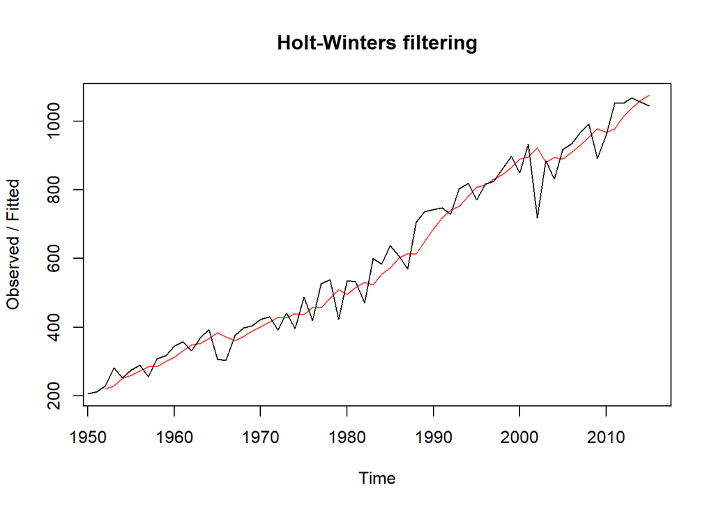

```r
plot(rice_prod_for)
```

In-sample Forecasting

```r
library(forecast)
forecast_data=forecast(rice_prod_for,h=5)
forecast_data
```

```
##      Point Forecast    Lo 80    Hi 80     Lo 95    Hi 95
## 2016       1080.614 1017.056 1144.172  983.4105 1177.818
## 2017       1095.139 1028.996 1161.281  993.9823 1196.295
## 2018       1109.663 1040.753 1178.574 1004.2742 1215.053
## 2019       1124.188 1052.334 1196.042 1014.2963 1234.080
## 2020       1138.713 1063.745 1213.681 1024.0588 1253.367
```

```r
library(Metrics)
actual_rice_production=c(1097, 1128, 1165, 1189, 1223)
predict_rice_production=c(1080.614, 1095.139, 1109.663, 1124.188, 1138.713)
```

**Root Mean Squared Error**

```r
result_1=rmse(actual_rice_production,predict_rice_production)
result_1
```

```
## [1] 56.06322
```

**Mean Absolute Percentage Error**

```r
result_2=mape(actual_rice_production,predict_rice_production)
result_2
```

```
## [1] 0.04299933
```

**Mean Absolute Scaled Error**

```r
result_3=mase(actual_rice_production,predict_rice_production)
result_3
```

```
## [1] 1.610686
```

**RESIDUAL ANALYSIS : HOLTS EXPONENTIAL SMOOTHING**

```r
#non-coliinearity check
res <- resid(forecast_data)
Box.test(res, type = "Ljung-Box")
```

```
##
##  Box-Ljung test
##
## data:  res
## X-squared = 0.4634, df = 1, p-value = 0.496
```

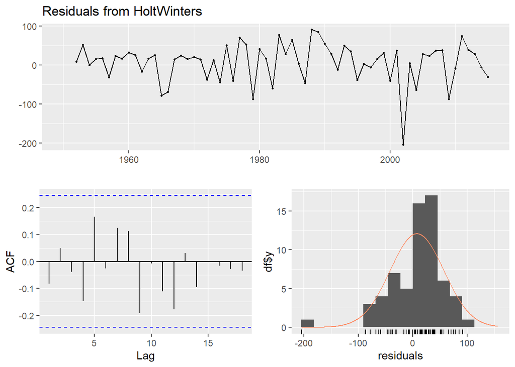

```r
forecast::checkresiduals(forecast_data)
```

```r
# normality test
shapiro.test(res)
```

```
##
##  Shapiro-Wilk normality test
##
## data:  res
## W = 0.90467, p-value = 0.0001206
```

**ARIMA MODEL**

```r
library(forecast)
fit=auto.arima(Rice_production2)
fit
```

```
## Series: Rice_production2
## ARIMA(0,1,1) with drift
##
## Coefficients:
##           ma1    drift
##       -0.7395  13.1848
## s.e.   0.0787   1.6337
##
## sigma^2 = 2406:  log likelihood = -344.65
## AIC=695.3   AICc=695.7   BIC=701.83
```

In-sample Forecasting

```r
forecast_rice_production<-forecast(fit,h=5)
forecast_rice_production
```

```
##      Point Forecast    Lo 80    Hi 80     Lo 95    Hi 95
## 2016       1075.780 1012.913 1138.646  979.6341 1171.926
## 2017       1088.965 1024.000 1153.930  989.6092 1188.320
## 2018       1102.149 1035.151 1169.147  999.6849 1204.614
## 2019       1115.334 1046.363 1184.305 1009.8521 1220.816
## 2020       1128.519 1057.630 1199.408 1020.1033 1236.935
```

```r
library(Metrics)
actual_rice_production=c(1097, 1128, 1165, 1189, 1223)
predict_rice_production=c(1075.780, 1088.965, 1102.149, 1115.334, 1128.519)
```

**Root Mean Squared Error**

```r
result_1=rmse(actual_rice_production,predict_rice_production)
result_1
```

```
## [1] 63.68298
```

**Mean Absolute Percentage Error**

```r
result_2=mape(actual_rice_production,predict_rice_production)
result_2
```

```
## [1] 0.04942165
```

**Mean Absolute Scaled Error**

```r
result_3=mase(actual_rice_production,predict_rice_production)
result_3
```

```
## [1] 1.849225
```

**RESIDUAL ANALYSIS: ARIMA**

```r
res <- resid(fit)
Box.test(res, type = "Ljung-Box")
```

```
##
##  Box-Ljung test
##
## data:  res
## X-squared = 0.38895, df = 1, p-value = 0.5329
```

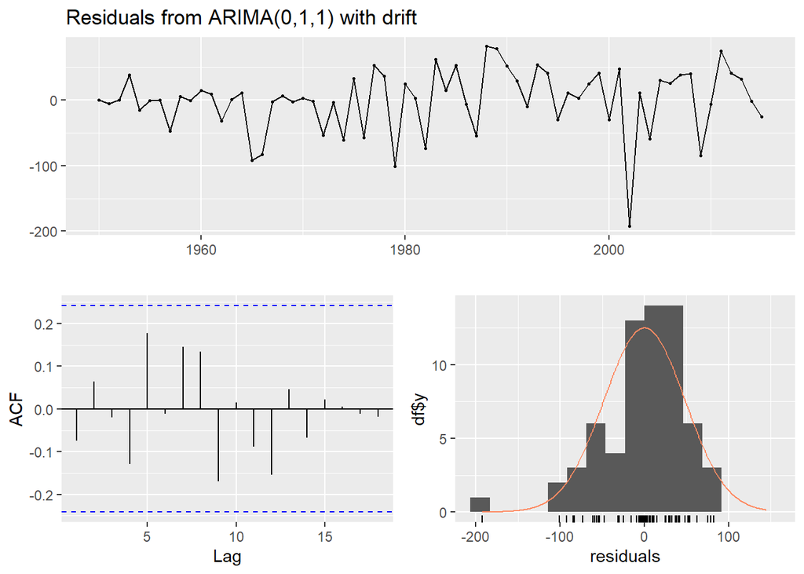

```
##
##  Ljung-Box test
##
## data:  Residuals from ARIMA(0,1,1) with drift
## Q* = 9.5332, df = 9, p-value = 0.3896
##
## Model df: 1.   Total lags used: 10
```

```r
forecast::checkresiduals(fit)
```

```r
# normality test
shapiro.test(res)
```

```
##
##  Shapiro-Wilk normality test
##
## data:  res
## W = 0.92161, p-value = 0.0004701
```

As we can see that the RMSE of HOLT is less than ARIMA, we can say HOLT is the best model here.

**FORECASTING USING THE BEST MODEL: HOLT**

```r
library(astsa)
rice_prod_for1=HoltWinters(Rice_production,gamma = FALSE)
library(forecast)
forecast_data_final=forecast(rice_prod_for1,h=5)
forecast_data_final
```

```
##      Point Forecast    Lo 80    Hi 80    Lo 95    Hi 95
## 2021       1210.112 1147.971 1272.252 1115.076 1305.147
## 2022       1227.818 1162.750 1292.886 1128.305 1327.331
## 2023       1245.525 1177.312 1313.737 1141.203 1349.847
## 2024       1263.231 1191.666 1334.797 1153.782 1372.681
## 2025       1280.938 1205.822 1356.054 1166.058 1395.818
```

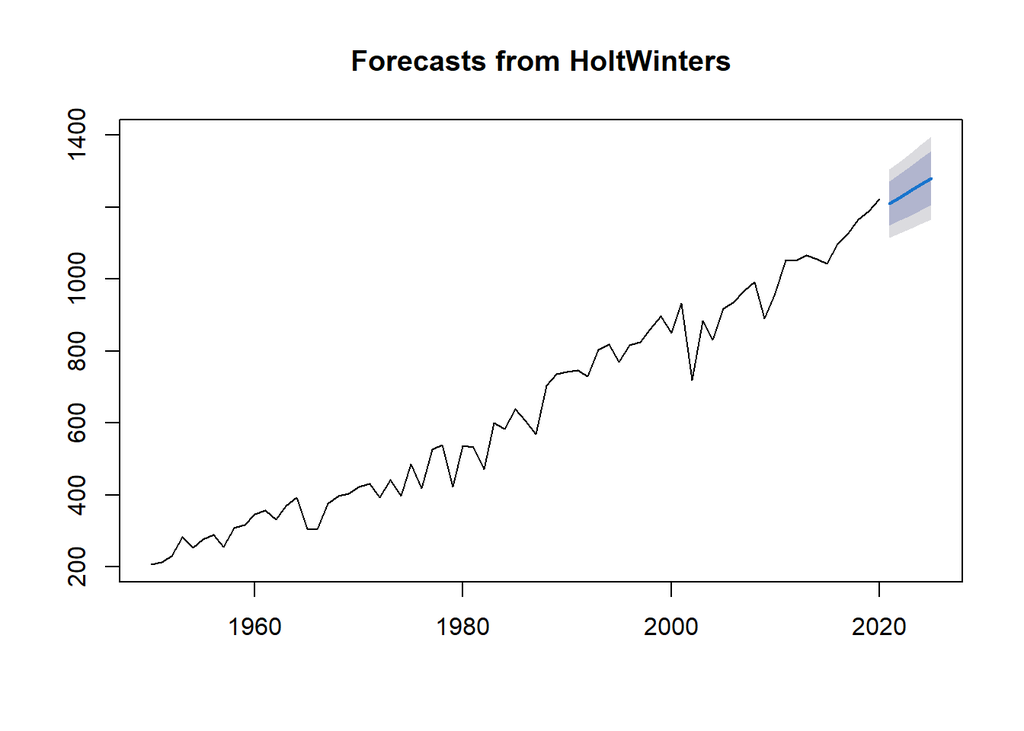

```r
plot(forecast_data_final)
```

**Finally we have forecasted using Holts exponential smoothing for the next 5 years rice production in India.**

**Making the data Stationary by using Method of Differencing.**

```r
diff_Rice_production=diff(Rice_production)
```

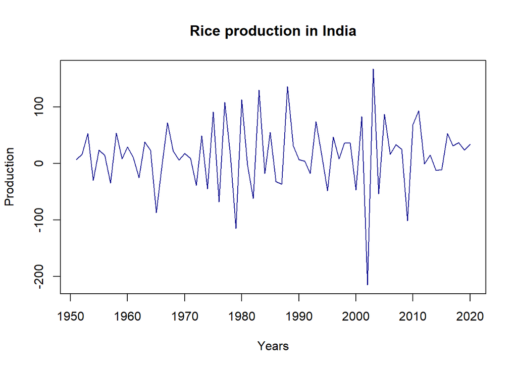

```r
ts.plot(diff_Rice_production,main='Rice production in India', xlab='Years', ylab='Production', col='darkblue')
```

Null Hypothesis: The series is non-stationary Alternate Hypothesis: The series is stationary

```r
adf.test(diff_Rice_production)
```

```
##
##  Augmented Dickey-Fuller Test
##
## data:  diff_Rice_production
## Dickey-Fuller = -5.6976, Lag order = 4, p-value = 0.01
## alternative hypothesis: stationary
```

Since p value obtained 0.01 which is less than 5% significance level, we could conclude that the data is stationary.